# Impact of large dams on food webs

The goal of this notebook is to quantify the impact of large dams (see [D12-dam-impact-presence.qmd]) on food web structure. To do so, we need to

- find descriptors of food web structure that can capture changes induced by dams
- these descriptors can be based on presence-absence data or account for species biomass
- model the impact of dams on these descriptors
- investigate how the dam impact is mediated by species
- synthetise dam impacts and species-mediated effect on all descriptors
- investigate model residuals to see where the models fail

## Setup

```r
library(renv)
renv::load()
library(targets)
library(here)
tar_config_set(
  store = here::here("_targets")
)
library(ggplot2)
library(dplyr)
devtools::load_all()
nice_theme()
```

## Descriptors of food web structure

### List of descriptors

We use the visits of the presence models of D12 (target `dam_visit`) and their observed food webs (D11), built from size classes: each fish species is split into classes of body length that set its diet. For each web we measure two types of metrics.

First, metrics based on presence-absence:

- **fish richness**: the number of fish species present
- **mean trophic level**: mean trophic level over the fish size classes
- **fish diet overlap**: the mean Jaccard similarity of the prey sets over pairs of fish size classes
- **trophic redundancy**: one minus the number of distinct trophic roles divided by the number of fish size classes, a role being a unique set of prey and predators.

Second, metrics based on biomass:

- **total biomass**: biomass summed over all individuals
- **mean trophic level**: the mean trophic level over the fish size classes, weighted by their biomass
- **biomass-trophic level correlation**: the correlation between log biomass and trophic level of fish size classes.

### An illustrative example

To see what each metric measures, we compute them on a small invented web., with The web as four species (A to D), split into two size classes for B, C and D, and A has a single size class. D plays the role of a top predator, we look at how the metrics respond to its loss.

```r
metric_label <- c(
  fish_richness = "Fish richness",
  mean_trophic_level = "Mean trophic level",
  fish_diet_overlap = "Fish diet overlap",
  trophic_redundancy = "Trophic redundancy",
  log_biomass = "Total biomass (log)",
  biomass_trophic_level = "Mean trophic level (biomass)",
  biomass_pyramid = "Biomass-trophic level correlation"
)
example_resource <- c("biofilm", "detritus", "insect")
example_diet <- list(
  insect = c("biofilm", "detritus"),
  A_1 = c("biofilm", "insect"),
  B_1 = c("biofilm", "insect"),
  B_2 = c("insect", "A_1", "B_1"),
  C_1 = c("insect", "A_1", "B_1"),
  C_2 = c("insect", "B_2", "C_1"),
  D_1 = "insect",
  D_2 = c("B_2", "C_1", "C_2")
)
example_biomass <- c(
  A_1 = 900, B_1 = 1200, B_2 = 400, C_1 = 350, C_2 = 150, D_1 = 200, D_2 = 800
)
example_node <- c("biofilm", "detritus", names(example_diet))
example_full <- matrix(
  0L, length(example_node), length(example_node),
  dimnames = list(example_node, example_node)
)
for (predator in names(example_diet)) {
  example_full[example_diet[[predator]], predator] <- 1L
}
example_kept <- !startsWith(example_node, "D_")
example_web <- list(
  `Full web` = example_full,
  `Without species D` = example_full[example_kept, example_kept]
)
example_metric <- purrr::map_dfr(
  example_web, measure_web, resource = example_resource,
  biomass = example_biomass, .id = "web"
)
```

Here are the web we consider for our illustrative exercise.

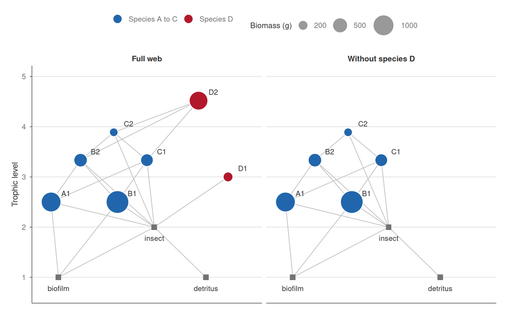

```r
example_x <- c(
  biofilm = 1, detritus = 3, insect = 2.3, A_1 = 0.9, B_1 = 1.8, B_2 = 1.3,
  C_1 = 2.2, C_2 = 1.75, D_1 = 3.3, D_2 = 2.9
)
example_position <- purrr::imap_dfr(example_web, \(foodweb, web) tibble(
  web, node = colnames(foodweb),
  level = compute_prey_averaged_trophic_level(
    igraph::graph_from_adjacency_matrix(foodweb), example_resource
  ),
  x = example_x[node]
))
example_link <- purrr::imap_dfr(example_web, \(foodweb, web) {
  link <- which(foodweb > 0, arr.ind = TRUE)
  tibble(web, prey = rownames(foodweb)[link[, 1]], predator = colnames(foodweb)[link[, 2]])
}) |>
  left_join(example_position, by = c("web", "prey" = "node")) |>
  left_join(example_position, by = c("web", "predator" = "node"), suffix = c("", "_end"))
example_fish <- example_position |>
  filter(!node %in% example_resource) |>
  mutate(
    biomass = example_biomass[node],
    species = if_else(startsWith(node, "D_"), "Species D", "Species A to C"),
    label = sub("_", "", node)
  )
ggplot() +
  geom_segment(
    data = example_link, aes(x, level, xend = x_end, yend = level_end),
    color = "grey75", linewidth = 0.4
  ) +
  geom_point(
    data = filter(example_position, node %in% example_resource), aes(x, level),
    shape = 15, size = 3, color = "grey45"
  ) +
  geom_text(
    data = filter(example_position, node %in% example_resource),
    aes(x, level, label = node), nudge_y = -0.22, size = 3.3, color = "grey20"
  ) +
  geom_point(
    data = example_fish, aes(x, level, size = biomass, fill = species),
    shape = 21, color = "white", stroke = 0.8
  ) +
  geom_text(
    data = example_fish, aes(x, level, label = label),
    nudge_x = 0.2, nudge_y = 0.17, size = 3.3, color = "grey20"
  ) +
  facet_wrap(~web) +
  scale_size_area(max_size = 13, breaks = c(200, 500, 1000)) +
  scale_fill_manual(values = c(`Species A to C` = "#2166AC", `Species D` = "#B2182B")) +
  scale_x_continuous(NULL, breaks = NULL, expand = expansion(mult = 0.1)) +
  scale_y_continuous(breaks = 1:5, limits = c(0.7, 5)) +
  guides(
    fill = guide_legend(override.aes = list(size = 5)),
    size = guide_legend(override.aes = list(fill = "grey60"))
  ) +
  labs(y = "Trophic level", size = "Biomass (g)", fill = NULL) +
  theme(legend.position = "top", panel.grid.minor = element_blank())
```

And here are the values of the selected metrics for the two webs.

```r
example_metric |>
  tidyr::pivot_longer(-web, names_to = "metric") |>
  filter(metric %in% names(metric_label)) |>
  tidyr::pivot_wider(names_from = web) |>
  mutate(metric = factor(metric_label[metric], metric_label)) |>
  arrange(metric) |>
  rename(Metric = metric) |>
  knitr::kable(digits = 2)
```

| Metric | Full web | Without species D |
| --- | --- | --- |
| Fish richness | 4.00 | 3.00 |
| Mean trophic level | 3.30 | 3.11 |
| Fish diet overlap | 0.30 | 0.39 |
| Trophic redundancy | 0.29 | 0.40 |
| Total biomass (log) | 8.29 | 8.01 |
| Mean trophic level (biomass) | 3.14 | 2.78 |
| Biomass-trophic level correlation | -0.31 | -0.99 |

Without D, species richness and biomass drops. The food web also becomes simpler, which is capture by a lower mean trophic level and higher trophic redundancy. Finally, more of the biomass is at the base of the web, which is captured by the decrease of the biomass-trophic level correlation, which goes to -1.

### Metrics observed in reconsutructred food webs

We exclude the 28 webs in which a fish size class has no prey, as its trophic level would then be that of a basal resource.

```r
web <- tar_read(dam_foodweb)
```

We first plot the distribution of the metrics over the webs of the visits.

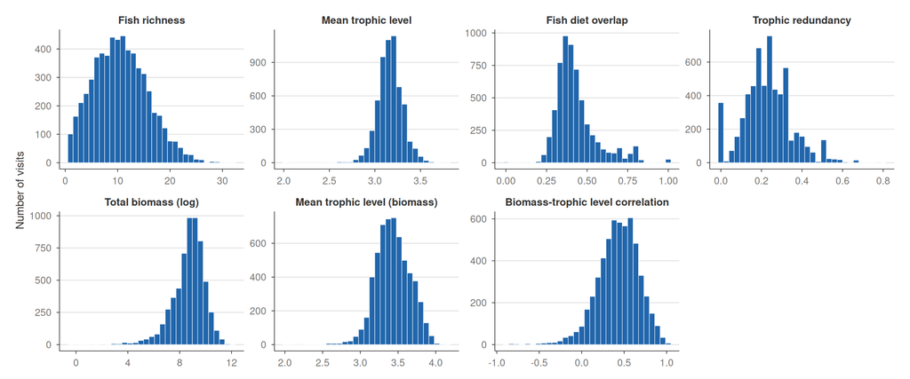

```r
web |>
  select(all_of(names(metric_label))) |>
  tidyr::pivot_longer(everything(), names_to = "metric") |>
  mutate(metric = factor(metric_label[metric], metric_label)) |>
  ggplot(aes(value)) +
  geom_histogram(
    # One bin per value for the counts (richness), 30 bins otherwise.
    binwidth = \(x) if (all(x == round(x))) 1 else diff(range(x)) / 30,
    fill = "#2166AC", color = "white", linewidth = 0.2, na.rm = TRUE
  ) +
  facet_wrap(~metric, scales = "free", ncol = 4) +
  labs(x = NULL, y = "Number of visits")
```

And the Spearman correlation between the metrics over the webs.

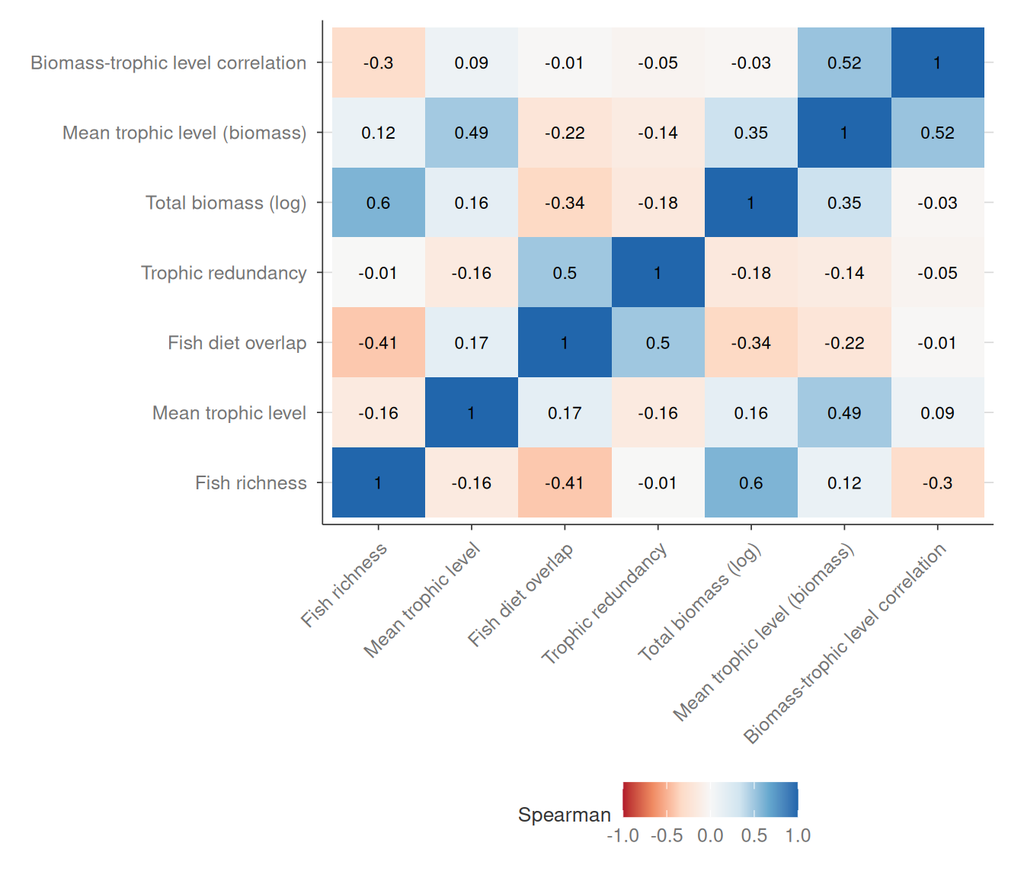

```r
web |>
  select(all_of(names(metric_label))) |>
  cor(method = "spearman", use = "pairwise.complete.obs") |>
  as_tibble(rownames = "x") |>
  tidyr::pivot_longer(-x, names_to = "y", values_to = "rho") |>
  mutate(across(c(x, y), \(v) factor(metric_label[v], metric_label))) |>
  ggplot(aes(x, y, fill = rho)) +
  geom_tile() +
  geom_text(aes(label = round(rho, 2)), size = 3) +
  scale_fill_distiller(palette = "RdBu", limits = c(-1, 1), direction = 1) +
  labs(x = NULL, y = NULL, fill = "Spearman") +
  theme(axis.text.x = element_text(angle = 45, hjust = 1))
```

To see how the metrics play together, we also run a principal component analysis on the scaled metrics of the visits where all of them are defined.

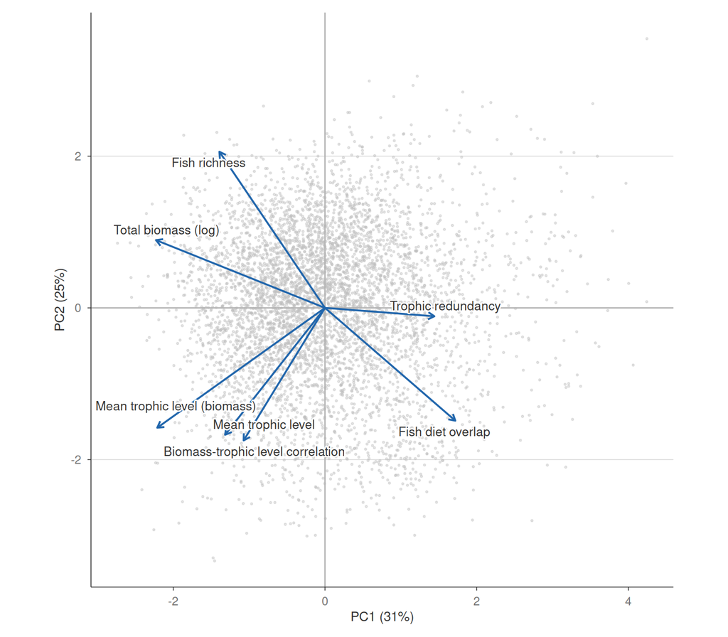

```r
web_pca <- tar_read(structure_pca)
pca_variance <- round(100 * summary(web_pca)$importance["Proportion of Variance", ])
pca_axis <- paste0(names(pca_variance), " (", pca_variance, "%)")
# Correlation of each metric with the axes.
pca_correlation <- as_tibble(t(t(web_pca$rotation) * web_pca$sdev), rownames = "metric") |>
  mutate(metric = metric_label[metric])
arrow_length <- 3 # Stretches the correlations to the range of the visits.
ggplot() +
  geom_point(
    data = as_tibble(web_pca$x), aes(PC1 / sd(PC1), PC2 / sd(PC2)),
    color = "grey75", size = 0.5, alpha = 0.4
  ) +
  geom_hline(yintercept = 0, color = "grey70") +
  geom_vline(xintercept = 0, color = "grey70") +
  geom_segment(
    data = pca_correlation,
    aes(0, 0, xend = arrow_length * PC1, yend = arrow_length * PC2),
    color = "#2166AC", linewidth = 0.7, arrow = arrow(length = unit(2, "mm"))
  ) +
  ggrepel::geom_text_repel(
    data = pca_correlation,
    aes(arrow_length * PC1, arrow_length * PC2, label = metric),
    size = 3.5, color = "grey20", seed = 1, min.segment.length = Inf,
    bg.color = "white", bg.r = 0.15
  ) +
  coord_equal() +
  labs(x = pca_axis[1], y = pca_axis[2])
```

Loading of each metric with the first two axes.

```r
pca_correlation |>
  select(Metric = metric, PC1, PC2) |>
  rename_with(\(x) pca_axis[match(x, names(pca_variance))], c(PC1, PC2)) |>
  knitr::kable(digits = 2)
```

| Metric | PC1 (31%) | PC2 (25%) |
| --- | --- | --- |
| Fish richness | -0.46 | 0.69 |
| Mean trophic level | -0.44 | -0.56 |
| Fish diet overlap | 0.57 | -0.50 |
| Trophic redundancy | 0.48 | -0.04 |
| Total biomass (log) | -0.74 | 0.30 |
| Mean trophic level (biomass) | -0.74 | -0.53 |
| Biomass-trophic level correlation | -0.36 | -0.58 |

```r
species_presence <- tar_read(species_presence)
pca_score <- scale(predict(web_pca, web)[, c("PC1", "PC2")])
axis_name <- c(PC1 = "PC1", PC2 = "PC2")
complete_visit <- complete.cases(pca_score)
composition_presence <- species_presence[complete_visit, ]
```

We investigate also how species presence influence PCA axis. For each axis, we keep the four species with the highest and the four with the lowest correlation.

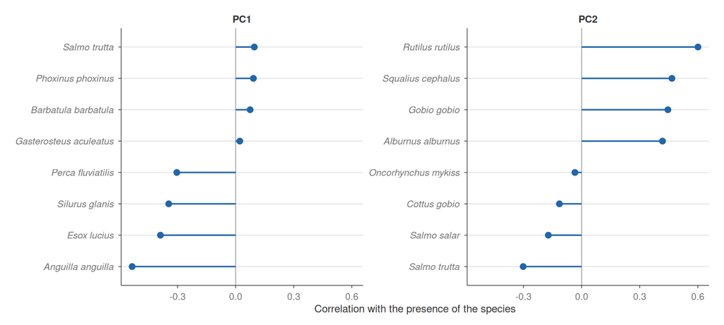

```r
frequent_presence <- composition_presence[, colSums(composition_presence) >= 100]
purrr::map_dfr(names(axis_name), \(axis) tibble(
  label = axis_name[axis],
  species = colnames(frequent_presence),
  correlation = apply(frequent_presence, 2, \(x) cor(x, pca_score[complete_visit, axis]))
)) |>
  (\(x) bind_rows(
    slice_max(x, correlation, n = 4, by = label),
    slice_min(x, correlation, n = 4, by = label)
  ))() |>
  mutate(species = reorder(paste(species, label, sep = "___"), correlation)) |>
  ggplot(aes(correlation, species)) +
  geom_vline(xintercept = 0, color = "grey70") +
  geom_segment(aes(x = 0, xend = correlation, yend = species), color = "#2166AC", linewidth = 0.7) +
  geom_point(color = "#2166AC", size = 2.5) +
  scale_y_discrete(labels = \(x) sub("___.*", "", x)) +
  facet_wrap(~label, scales = "free_y") +
  labs(x = "Correlation with the presence of the species", y = NULL) +
  theme(axis.text.y = element_text(face = "italic"))
```

Map of mean score of each site on the two CPA axes, over its visits.

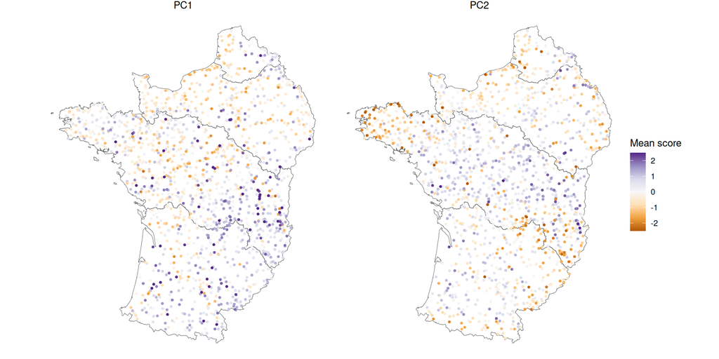

```r
basin_kept <- tar_read(basin) |>
  filter(district %in% tar_read(params)$district_kept)
site_axis <- web |>
  mutate(PC1 = pca_score[, "PC1"], PC2 = pca_score[, "PC2"]) |>
  filter(complete_visit) |>
  mutate(PC1 = mean(PC1), PC2 = mean(PC2), .by = sandre_code) |>
  distinct(sandre_code, .keep_all = TRUE)
site_location <- visit_coordinates(site_axis) * 1000
site_axis |>
  transmute(x = site_location[, 1], y = site_location[, 2], PC1, PC2) |>
  tidyr::pivot_longer(c(PC1, PC2), names_to = "axis", values_to = "score") |>
  mutate(axis = axis_name[axis]) |>
  arrange(abs(score)) |>
  ggplot() +
  geom_sf(data = sf::st_transform(basin_kept, 2154), fill = NA, color = "grey40") +
  geom_point(aes(x, y, color = score), size = 0.8) +
  facet_wrap(~axis) +
  scale_color_distiller(
    palette = "PuOr", direction = 1, limits = c(-2.5, 2.5),
    oob = scales::squish, name = "Mean score"
  ) +
  theme_void() +
  theme(strip.text = element_text(size = 11))
```

No single axis sums up all the food web structure. Yet, the first two axes explain together more than half of it.

**PC1.** PC1 is about how simple the web is. Low scores are rich webs holding much biomass, high in the web; high scores are webs with few species, little biomass, low in the web, and fish that are alike (high diet overlap and trophic redundancy). Low scores are found in webs with the eel, the pike or the wels catfish; we call it the simplicity axis.

**PC2.** PC2 opposes species-poor webs where the biomass is concentrated high in the web, often with brown trout, to species-rich webs that are less top-heavy, with more biomass in species feeding low in the web. We call it the richness to top-heaviness gradient. It could indicate polluted water, as it is strongly correlated with the presence of *Rutilus rutilus* which is a species known to tolerate polluted water, and take strong values in estuaries.

## Model dam impacts on food web structure

We model the impacts of dams on food web descriptors using the model structure from presence models (see notebook D12). We use Gaussian distribution except for fish richness for which we use a Poisson distribution (because it seems *a propos*). In addition of the descriptors listed above, we also model the scores of the two PCA axes.

```r
structure_setting <- tar_read(structure_setting)
structure_effect <- purrr::map2_dfr(
  tar_read(structure_model), structure_setting$richness,
  \(model, richness) model$summary.fixed |>
    as_tibble(rownames = "term") |>
    transmute(
      metric = model$metric, richness, term,
      mean, lower = `0.045quant`, upper = `0.955quant`
    )
) |>
  filter(metric %in% names(metric_label)) |>
  left_join(
    web |>
      summarise(across(all_of(names(metric_label)), \(x) sd(x, na.rm = TRUE))) |>
      tidyr::pivot_longer(everything(), names_to = "metric", values_to = "sd"),
    by = "metric"
  ) |>
  # Gaussian metrics on the sd scale, to compare them; richness stays on the
  # log scale.
  mutate(
    across(c(mean, lower, upper), \(x) if_else(metric == "fish_richness", x, x / sd)),
    control = if_else(richness, "with richness", "without richness")
  )
```

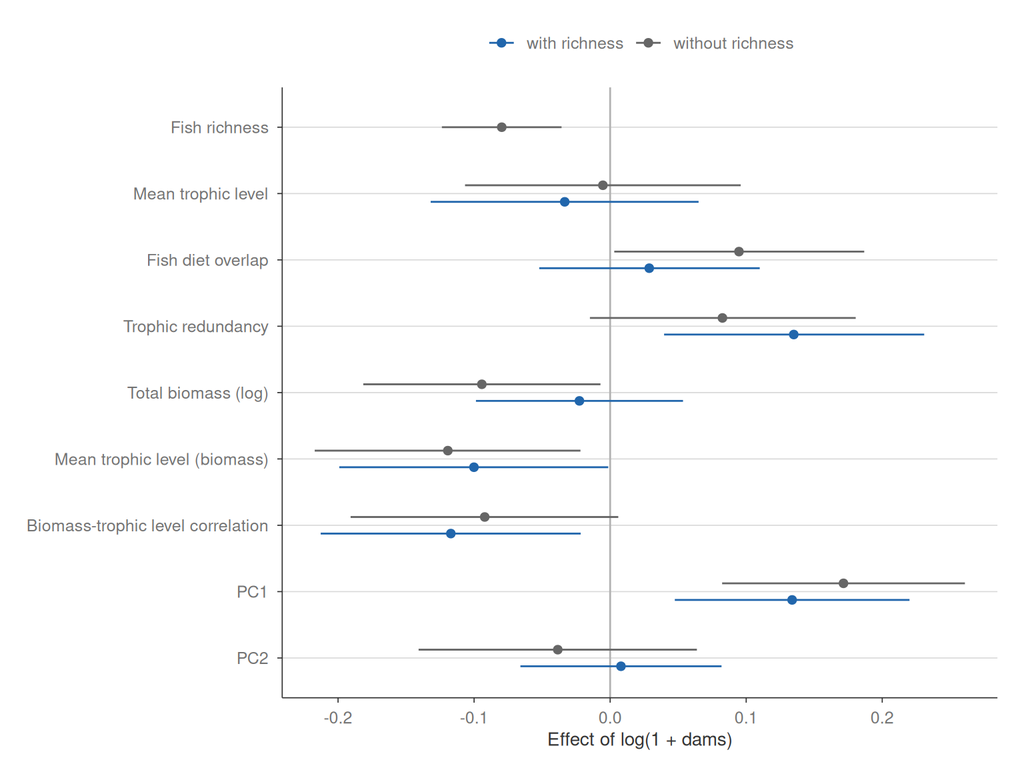

```r
structure_label <- c(
  metric_label,
  PC1 = "PC1", PC2 = "PC2"
)
structure_axis_setting <- tar_read(structure_axis_setting)
axis_effect <- purrr::map_dfr(seq_len(nrow(structure_axis_setting)), \(i) {
  dam <- tar_read(structure_axis_model)[[i]]$summary.fixed["accumulation", ]
  tibble(
    metric = structure_axis_setting$axis[i],
    control = if_else(structure_axis_setting$richness[i], "with richness", "without richness"),
    mean = dam$mean, lower = dam$`0.045quant`, upper = dam$`0.955quant`
  )
})
structure_effect |>
  filter(term == "accumulation") |>
  bind_rows(axis_effect) |>
  mutate(metric = factor(structure_label[metric], rev(structure_label))) |>
  ggplot(aes(mean, metric, color = control)) +
  geom_vline(xintercept = 0, color = "grey70") +
  geom_pointrange(
    aes(xmin = lower, xmax = upper),
    position = position_dodge(0.5), size = 0.3
  ) +
  scale_color_manual(values = c(`without richness` = "grey40", `with richness` = "#2166AC")) +
  labs(x = "Effect of log(1 + dams)", y = NULL, color = NULL) +
  theme(legend.position = "top")
```

## How species mediate dam effect on food web structure

We now ask which species mediate the dam effect on food web structure. We summarise the structure with PC1 for simplicity. We do this in 3 steps.

1. **Species contribution to structure.** Each fish species of each web is removed in turn (all its size classes), and PC1 is computed again on the remaining web (webs with at least 3 fish species). We note $r_s$ the change of PC1 when species $s$ is removed, in standard deviations of PC1, averaged over the visits of each site and then over the sites.
2. **Dam impact on species presence.** With the presence models of D12, one more unit of $\log(1 + \text{dams})$ changes the presence probability of species $s$ by $\beta_s \overline{p_s (1 - p_s)}$, with $\beta_s$ its dam effect on the logit scale and $p_s$ its fitted presence probability, averaged over the visits.
3. **Combining the two.** The contribution of species $s$ to the dam effect on PC1 is its change of presence times the change of PC1 that its presence brings, and the expected dam effect is the sum over the species:
   $$\Delta = \sum_s \beta_s \, \overline{p_s (1 - p_s)} \, (-r_s).$$

The uncertainty of $\beta_s$ and $r_s$ is propagated by drawing both. To know whether dams affect the species that matter more for the structure, we compare $\Delta$ with a null model where the dam effects $\beta_s$ are shuffled among the species: the loss is as large, but falls on random species.

```r
presence_model <- tar_read(presence_model)
decomposition <- tar_read(structure_decomposition)
permutation <- tar_read(structure_permutation)
species_step <- c(
  importance = "Contribution to PC1",
  presence = "Dam impact on presence",
  contribution = "Dam effect mediated by the species"
)
species_mediation <- decomposition$species |>
  filter(metric == "PC1") |>
  left_join(select(filter(tar_read(species_removal_effect), metric == "PC1"), species, importance = mean,
                   importance_lower = lower, importance_upper = upper), by = "species")
```

We plot the dam effect on PC1 estimated by the model, predicted from the loss of species to dam, and predicted using the same loss but randomised among species, without and at equal richness. To predict the effect at equal richness, the change of PC1 when a species is removed is corrected by the change expected from having one species fewer, that is the effect of log richness in the model of PC1 with richness times the change of log richness when the species is removed.

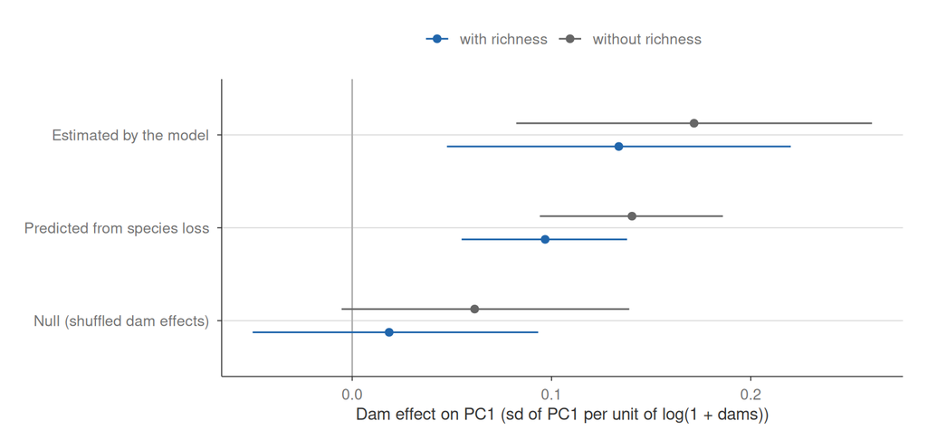

```r
estimate_level <- c(
  "Estimated by the model", "Predicted from species loss", "Null (shuffled dam effects)"
)
metric_control <- c(PC1 = "without richness", PC1_richness = "with richness")
bind_rows(
  axis_effect |>
    filter(metric == "PC1") |>
    transmute(estimate = estimate_level[1], control, mean, lower, upper),
  bind_rows(
    decomposition$draw |> mutate(estimate = estimate_level[2]),
    permutation |> mutate(estimate = estimate_level[3])
  ) |>
    summarise(
      mean = mean(change), lower = quantile(change, 0.045), upper = quantile(change, 0.955),
      .by = c(metric, estimate)
    ) |>
    transmute(estimate, control = metric_control[metric], mean, lower, upper)
) |>
  mutate(estimate = factor(estimate, rev(estimate_level))) |>
  ggplot(aes(mean, estimate, color = control)) +
  geom_vline(xintercept = 0, color = "grey70") +
  geom_pointrange(
    aes(xmin = lower, xmax = upper),
    position = position_dodge(0.5), size = 0.3
  ) +
  scale_color_manual(values = c(`without richness` = "grey40", `with richness` = "#2166AC")) +
  labs(x = "Dam effect on PC1 (sd of PC1 per unit of log(1 + dams))", y = NULL, color = NULL) +
  theme(legend.position = "top")
```

Next we plot the decomposition of the predicted effect from species loss at the species level. We keep the species with the stronger mediated effect.

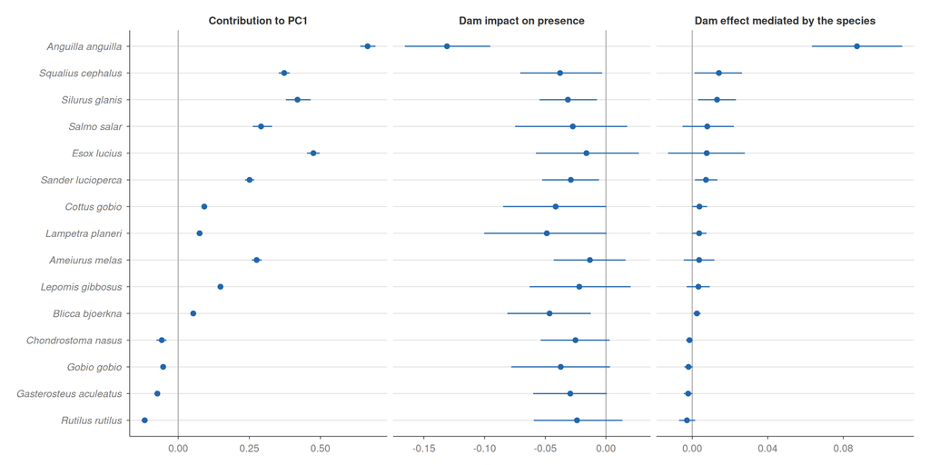

```r
bind_rows(
  species_mediation |> transmute(species, step = "importance", mean = importance, lower = importance_lower, upper = importance_upper),
  species_mediation |> transmute(species, step = "presence", mean = presence, lower = presence_lower, upper = presence_upper),
  species_mediation |> transmute(species, step = "contribution", mean = contribution, lower, upper)
) |>
  semi_join(slice_max(species_mediation, abs(contribution), n = 15), by = "species") |>
  mutate(
    step = factor(species_step[step], species_step),
    species = factor(species, arrange(species_mediation, contribution)$species)
  ) |>
  ggplot(aes(mean, species)) +
  geom_vline(xintercept = 0, color = "grey70") +
  geom_pointrange(aes(xmin = lower, xmax = upper), size = 0.3, color = "#2166AC") +
  facet_wrap(~step, scales = "free_x") +
  labs(x = NULL, y = NULL) +
  theme(axis.text.y = element_text(face = "italic"))
```

Species have varied influence on food web structure, and piscivores are the most important ones. Dams also affect species unequally, and the eel far more than any other species. Overall, this makes the eel, a large catadromous piscivore, the main species mediating the dam impact.

To separate the number of species lost from their identity, we split the predicted effect. With $a_s = \beta_s \overline{p_s (1 - p_s)}$ the change of presence of species $s$, and $\bar{a}$ its mean over the species,
$$\Delta = \bar{a} \sum_s (-r_s) + \sum_s (a_s - \bar{a}) (-r_s).$$
The first term is the effect of the loss if dams hit all species equally (the number of species lost), and the second term sums, over the species, the effect of dams hitting a species more or less than the average one (which species are lost). The top bar is the predicted effect, split into these two parts, in percentage of the predicted effect. The bars below split the second part by species: starting where the first part ends, a species with a positive part moves to the right and one with a negative part to the left, so that the species bars end at the total.

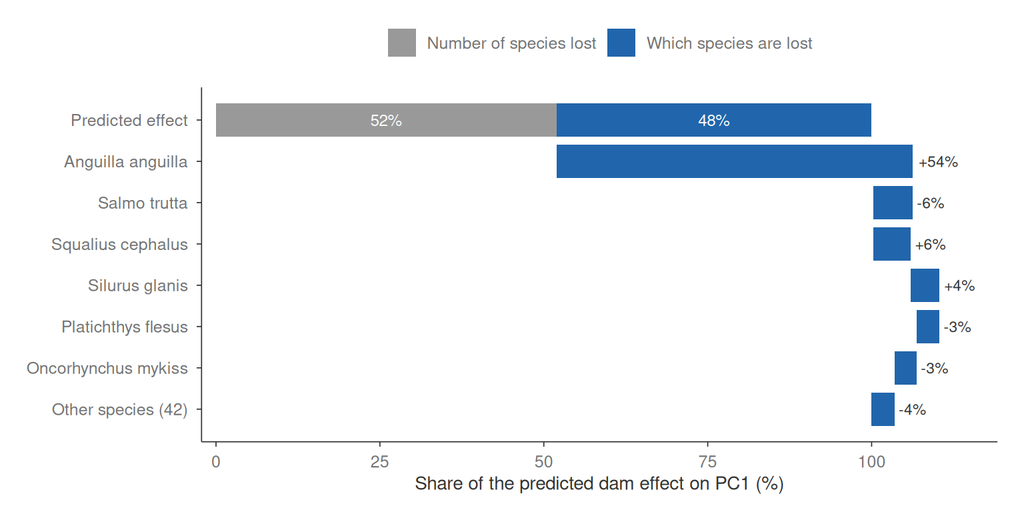

```r
mean_presence <- mean(species_mediation$presence)
species_identity <- species_mediation |>
  transmute(item = species, value = (presence - mean_presence) * -importance) |>
  arrange(desc(abs(value)))
n_shown <- 6
species_identity <- bind_rows(
  head(species_identity, n_shown),
  tibble(
    item = paste0("Other species (", nrow(species_identity) - n_shown, ")"),
    value = sum(species_identity$value[-seq_len(n_shown)])
  )
)
number_part <- mean_presence * sum(-species_mediation$importance)
total <- number_part + sum(species_identity$value)
# Parts in percentage of the predicted effect.
number_part <- 100 * number_part / total
species_identity <- mutate(species_identity, value = 100 * value / total)
split_part <- bind_rows(
  tibble(
    item = "Predicted effect",
    part = c("Number of species lost", "Which species are lost"),
    start = c(0, number_part), end = c(number_part, 100)
  ),
  species_identity |>
    mutate(
      end = number_part + cumsum(value), start = lag(end, default = number_part),
      part = "Which species are lost"
    )
) |>
  mutate(
    position = match(item, unique(item)),
    value = end - start
  )
ggplot(split_part) +
  geom_rect(
    aes(xmin = pmin(start, end), xmax = pmax(start, end),
        ymin = position - 0.4, ymax = position + 0.4, fill = part)
  ) +
  geom_text(
    aes(x = (start + end) / 2, y = position, label = sprintf("%.0f%%", value)),
    data = filter(split_part, position == 1), color = "white", size = 3.2
  ) +
  geom_text(
    aes(x = pmax(start, end), y = position, label = sprintf("%+.0f%%", value)),
    data = filter(split_part, position > 1), hjust = -0.15, color = "grey20", size = 3
  ) +
  scale_y_reverse(breaks = unique(split_part$position), labels = unique(split_part$item)) +
  scale_x_continuous(breaks = seq(0, 100, 25), expand = expansion(mult = c(0.02, 0.08))) +
  scale_fill_manual(values = c(`Number of species lost` = "grey60", `Which species are lost` = "#2166AC")) +
  labs(x = "Share of the predicted dam effect on PC1 (%)", y = NULL, fill = NULL) +
  theme(legend.position = "top", panel.grid.major.y = element_blank())
```